# Titanic - analiza danych o pasażerach

[figure not shown]

## O Danych

Dane o pasażerach Titanica

Zbiór danych zawiera informacje o pasażerach RMS Titanic, który zatonął 15 kwietnia 1912 roku po zderzeniu z górą lodową. Dane obejmują takie atrybuty jak klasa podróży, wiek, płeć, liczba rodzeństwa/małżonków na pokładzie, liczba rodziców/dzieci na pokładzie, cena biletu oraz miejsce zaokrętowania.

Zbiór zawiera także informację o tym, czy pasażer przeżył katastrofę.

Titanic przewoził ponad 2,200 osób, z czego ponad 1,500 zginęło, co czyni tę katastrofę jedną z najbardziej tragicznych w historii morskiej.

## O Danych

Kolumny:

- **pclass** - Klasa biletu
- **survived** - Czy pasażer przeżył katastrofę
- **name** - Imię i nazwisko pasażera
- **sex** - Płeć pasażera
- **age** - Wiek pasażera
- **sibsp** - Liczba rodzeństwa/małżonków na pokładzie
- **parch** - Liczba rodziców/dzieci na pokładzie
- **ticket** - Numer biletu
- **fare** - Cena biletu
- **cabin** - Numer kabiny
- **embarked** - Port, w którym pasażer wszedł na pokład (C = Cherbourg, Q = Queenstown, S = Southampton)
- **boat** - Numer łodzi ratunkowej
- **body** - Numer ciała (jeśli pasażer nie przeżył i ciało zostało odnalezione)
- **home.dest** - Miejsce docelowe

# 1. Przegląd i analiza danych dotyczących Titanica i jego pasażerów.

## 1.1 Wczytanie danych i przegląd losowych wartości.

|  | pclass | survived | name | sex | age | sibsp | parch |
| --- | --- | --- | --- | --- | --- | --- | --- |
| 701 | 3.0 | 0.0 | Calic, Mr. Petar | male | 17.0 | 0.0 | 0.0 |
| 994 | 3.0 | 0.0 | Mardirosian, Mr. Sarkis | male | NaN | 0.0 | 0.0 |
| 350 | 2.0 | 1.0 | Brown, Miss. Edith Eileen | female | 15.0 | 0.0 | 2.0 |
| 986 | 3.0 | 0.0 | Maenpaa, Mr. Matti Alexanteri | male | 22.0 | 0.0 | 0.0 |
| 409 | 2.0 | 0.0 | Fox, Mr. Stanley Hubert | male | 36.0 | 0.0 | 0.0 |
| 917 | 3.0 | 1.0 | Karun, Mr. Franz | male | 39.0 | 0.0 | 1.0 |

|  | ticket | fare | cabin | embarked | boat | body | home.dest |
| --- | --- | --- | --- | --- | --- | --- | --- |
| 701 | 315086 | 8.6625 | NaN | S | NaN | NaN | NaN |
| 994 | 2655 | 7.2292 | F E46 | C | NaN | NaN | NaN |
| 350 | 29750 | 39.0000 | NaN | S | 14 | NaN | Cape Town, South Africa / Seattle, WA |
| 986 | STON/O 2. 3101275 | 7.1250 | NaN | S | NaN | NaN | NaN |
| 409 | 229236 | 13.0000 | NaN | S | NaN | 236.0 | Rochester, NY |
| 917 | 349256 | 13.4167 | NaN | C | 15 | NaN | NaN |

#### Po wczytaniu danych mamy informację o 1310 wierszach i 14 kolumnach.

#### Zauważyć można, że w wierszu 1309, we wszystkich kolumnach są puste wartości, należy zatem usunąć ten wiersz przed przystąpieniem, do dalszej analizy.

#### Po przeglądzie losowych wartości widać, że istnieje wiele pustych wartości w niektórych kolumnach. W dalszej analizie, należy zastanowić się, czy brakujące wartości będą miały istotny wpływ na wyniki analizy i czy będzie potrzeba wypełnienia tych wartości.

#### Jeden z wierszy ma puste wartości we wszystkich kolumnach

|  | pclass | survived | name | sex | age | sibsp | parch | ticket | fare | cabin | embarked | boat | body | home.dest |
| --- | --- | --- | --- | --- | --- | --- | --- | --- | --- | --- | --- | --- | --- | --- |
| 1309 | NaN | NaN | NaN | NaN | NaN | NaN | NaN | NaN | NaN | NaN | NaN | NaN | NaN | NaN |

#### Usuwam wiersz z pustymi wartościami.

## 1.2 Sprawdzenie wartości unikatowych.

|  | 0 |
| --- | --- |
| pclass | 3 |
| survived | 2 |
| name | 1307 |
| sex | 2 |
| age | 98 |
| sibsp | 7 |
| parch | 8 |
| ticket | 929 |
| fare | 281 |
| cabin | 186 |
| embarked | 3 |
| boat | 27 |
| body | 121 |
| home.dest | 369 |

#### Krótkie spostrzeżenia o wartościach unikatowych:

- **pclass** - 3 klasy biletów (ilu pasażerów w każdej klasie)
- **survived** - 2 wartości oznaczające czy pasażer ocalał, czy nie(sprawdzić ilu ocalonych)
- **name** - 1307 nazwisk na 1309 rekordów (sprawdzić duplikaty)
- **sex** - 2 wartości oznaczające płeć (sprawdzić ile kobiet/mężczyzn)
- **age** - 98 wartości określających wiek (w losowych danych widać wiek podany jako ułamek, zamienić na liczby całkowite, ponownie sprawdzić wartości unikatowe)
- **sibsp** - 7 wartości dla liczby rodzeństwa/małżonków na pokładzie
- **parch** - 8 wartości dla rodziców/dzieci na pokładzie
- **ticket** - 929 wartości z numerem biletu (sprawdzić duplikaty, dlaczego występują)
- **fare** - 281 wartości z różną ceną biletu(sprawdzić od czego uzależniona cena)
- **cabin** - 186 numerów kabin
- **embarked** - 3 rożne porty wejścia pasażerów na pokład
- **boat** - 27 numerów łodzi ratunkowych(jakieś zależności?)
- **body** - 121 wartości dla odnalezionych ciał ofiar katastrofy
- **home.dest** - 369 wartości dla celu podróży pasażerów(sprawdzić korelację ocalony cel podrózy)

## 1.3 Przegląd danych statystycznych.

|  | pclass | survived | age | sibsp | parch | fare | body |
| --- | --- | --- | --- | --- | --- | --- | --- |
| count | 1309.000000 | 1309.000000 | 1046.000000 | 1309.000000 | 1309.000000 | 1308.000000 | 121.000000 |
| mean | 2.294882 | 0.381971 | 29.881135 | 0.498854 | 0.385027 | 33.295479 | 160.809917 |
| std | 0.837836 | 0.486055 | 14.413500 | 1.041658 | 0.865560 | 51.758668 | 97.696922 |
| min | 1.000000 | 0.000000 | 0.166700 | 0.000000 | 0.000000 | 0.000000 | 1.000000 |
| 25% | 2.000000 | 0.000000 | 21.000000 | 0.000000 | 0.000000 | 7.895800 | 72.000000 |
| 50% | 3.000000 | 0.000000 | 28.000000 | 0.000000 | 0.000000 | 14.454200 | 155.000000 |
| 75% | 3.000000 | 1.000000 | 39.000000 | 1.000000 | 0.000000 | 31.275000 | 256.000000 |
| max | 3.000000 | 1.000000 | 80.000000 | 8.000000 | 9.000000 | 512.329200 | 328.000000 |

##### Średnia cena biletu to 33. najtańszy bilet kosztował 0, najdroższy 512.

##### Odnaleziono 121 ciał.

# 2 Analiza brakujących wartości.

|  | 0 |
| --- | --- |
| pclass | 0 |
| survived | 0 |
| name | 0 |
| sex | 0 |
| age | 263 |
| sibsp | 0 |
| parch | 0 |
| ticket | 0 |
| fare | 1 |
| cabin | 1014 |
| embarked | 2 |
| boat | 823 |
| body | 1188 |
| home.dest | 564 |

#### Brakujące dane:

- **age** 263 dane o wieku (naprawić średnią dla mężczyzn i kobiet?)
- **fare** 1 cena biletu (naprawić średnią ceną)
- **cabin** 1014 danych o numerze kabiny
- **embarked** 2 informacje o porcie wejścia pasażerów na pokład
- **boat** 823 numer łodzi ratunkowej, w której przebywał pasażer (sprawdzic brakujące wartośći dla ocalałych pasażerów)
- **body** 1188 numer ciała
- **home.dst** 564 celu podróży.

# 3 Analiza poszczególnych danych.

#### PCLASS - ilość pasażerów w każdej klasie

| pclass | count |
| --- | --- |
| 1.0 | 323 |
| 2.0 | 277 |
| 3.0 | 709 |

[figure not shown]

##### Mamy tutaj 3 klasy, w których podróżowali pasażerowie.

##### W klasie 1 podróżowało 323 pasażerów, w klasie 2 podróżowało 277 pasażerów, w klasie 3 podróżowało 709 pasażerów.

#### SURVIVED - ilość ocalałych i ofiar

|  | Ilość |
| --- | --- |
| Zginęło | 809 |
| Przeżyło | 500 |

##### Katasrtofę przeżyło 500 pasażerów, zginęło 809 pasażerów.

#### SEX - ilość kobiet i mężczyzn wśród pasażerów, dane o ofiarach

|  | Ilość |
| --- | --- |
| Kobiet | 466 |
| Mężczyzn | 843 |

##### Wśród pasażerów było 466 i 843 mężczyzn

|  | Kobiet | Mężczyzn |
| --- | --- | --- |
| Zginęło | 127 | 682 |
| Przeżyło | 339 | 161 |

##### Spośród 500 ocalonych, przeżyło 339 kobiet i 161 meżczyzn.

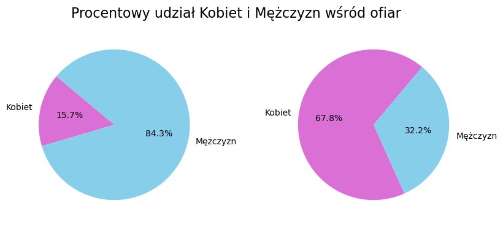

##### Ilość ocalonych pasażerów w każdej z klas

| pclass | survived |
| --- | --- |
| 1.0 | 200.0 |
| 2.0 | 119.0 |
| 3.0 | 181.0 |

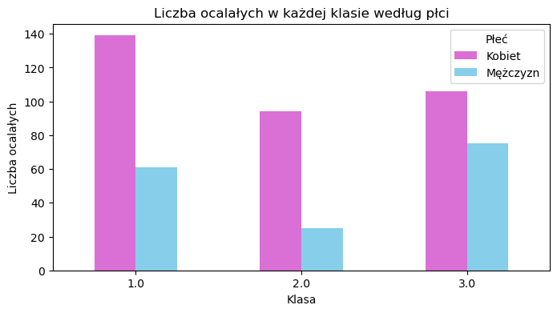

##### Podróżujących w klasie 1 ocalało 200 z 323 osób, w klasie 2 ocalało 119 z 277 osób, w klasie 3 ocalało 181 z 709 osób

#### AGE - wiek pasażerów

|  | 0 |
| --- | --- |
| 0 | 29.0000 |
| 1 | 0.9167 |
| 2 | 2.0000 |
| 3 | 30.0000 |
| 4 | 25.0000 |
| ... | ... |
| 94 | 60.5000 |
| 95 | 74.0000 |
| 96 | 0.4167 |
| 97 | 11.5000 |
| 98 | 26.5000 |

99 rows × 1 columns

##### Ponieważ wiek nie jest podany w liczbach całkowitych, zaokraglę go i zapiszę w nowej kolumnie

|  | 0 |
| --- | --- |
| 0 | 29.0 |
| 1 | 1.0 |
| 2 | 2.0 |
| 3 | 30.0 |
| 4 | 25.0 |
| ... | ... |
| 68 | 66.0 |
| 69 | 9.0 |
| 70 | 0.0 |
| 71 | 10.0 |
| 72 | 74.0 |

73 rows × 1 columns

##### Średni wiek pasażerów to blisko 30 lat, najmłodszy pasażer jest noworodkiem poniżej pół roku życia, najstrszy pasażer ma 80 lat.

|  | age_round |
| --- | --- |
| count | 1046.000000 |
| mean | 29.870937 |
| std | 14.411571 |
| min | 0.000000 |
| 25% | 21.000000 |
| 50% | 28.000000 |
| 75% | 39.000000 |
| max | 80.000000 |

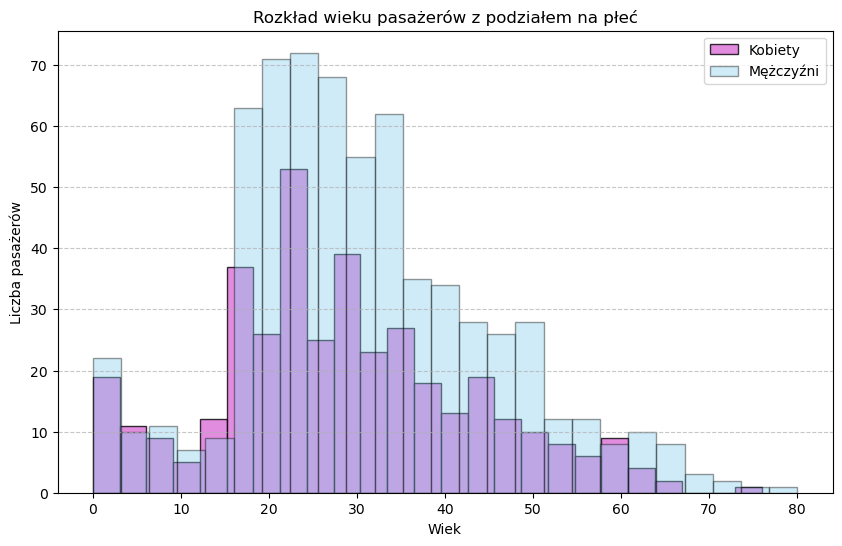

#### SIBSP - liczba rodzeństwa, małżonków na pokładzie

```
418 pasażerów było na pokładzie z rodzeństwem lub małżonkiem.
```

#### PARCH - liczba rodziców, dzieci na pokładzie

```
307 pasażerów było na pokładzie z rodzicem lub dzieckiem.
```

#### TICKET - numer biletu

|  | ticket |
| --- | --- |
| count | 1309 |
| unique | 929 |
| top | CA. 2343 |
| freq | 11 |

##### Numery biletu mają 929 wartości unikatowych, na 1309 pozycji, należy sprawdzić duplikaty.

#### FARE - cena biletu

| pclass | count | mean | std | min | 25% | 50% | 75% | max |
| --- | --- | --- | --- | --- | --- | --- | --- | --- |
| 1.0 | 323.0 | 87.508992 | 80.447178 | 0.0 | 30.6958 | 60.0000 | 107.6625 | 512.3292 |
| 2.0 | 277.0 | 21.179196 | 13.607122 | 0.0 | 13.0000 | 15.0458 | 26.0000 | 73.5000 |
| 3.0 | 708.0 | 13.302889 | 11.494358 | 0.0 | 7.7500 | 8.0500 | 15.2458 | 69.5500 |

##### Najdroższy bilet miał cenę 512, najtańsze 0.

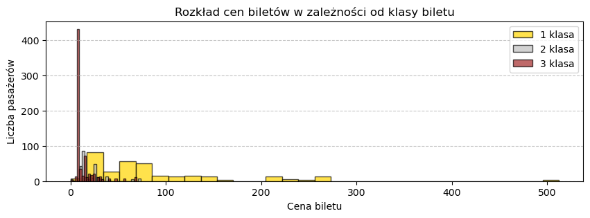

##### Bardzo duża rozpiętość cen biletów, zwlaszcza w klasie 1. Najwięcej wartośći zarejestrowanych w okolicy 10 dla klasy 3.

##### Dla lepszego zobrazowania dla klas 1 i 2, wykres z ograniczonym zakresem

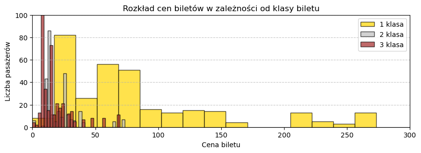

#### CABIN - numer kabiny

|  | cabin |
| --- | --- |
| count | 295 |
| unique | 186 |
| top | C23 C25 C27 |
| freq | 6 |

##### Mamy informacje o 295 kabinach, które posiadają 186 wartości unikatowych.

#### EMBARKED - port wejścia na pokład

| embarked | count |
| --- | --- |
| S | 914 |
| C | 270 |
| Q | 123 |

##### Mamy dane na temat 3 portów, w których pasażerowie wchodzili na pokład.

##### S = Southampton - 914 pasażerów

##### C = Cherbourg - 270 paseżerów

##### Q = Queenstown - 123 pasażerów

#### BOAT - numer łodzi ratunkowej

|  | boat |
| --- | --- |
| count | 486 |
| unique | 27 |
| top | 13 |
| freq | 39 |

##### Mamy informacje o 27 unikatowych numerach łodzi ratunkowcyh.

#### BODY - numer ciała jeśli pasażer nie przeżył i ciało zostało odnalezione

|  | 0 |
| --- | --- |
| 0 | NaN |
| 1 | 135.0 |
| 2 | 22.0 |
| 3 | 124.0 |
| 4 | 148.0 |
| ... | ... |
| 117 | 14.0 |
| 118 | 131.0 |
| 119 | 312.0 |
| 120 | 328.0 |
| 121 | 304.0 |

122 rows × 1 columns

##### Mamy informacje o 121 unikatowych numerach odnalezionych ciał.

#### HOME.DEST - miejsce docelowe podróżujących

[figure not shown]